# Homework 03 — Working Guide

## Question 2: Ridge regression with nearly collinear predictors

**Goal:** Run a simulation comparing OLS and ridge regression when two predictors contain almost the same information. Then use your results to interpret coefficient stability and prediction error.

This is a guide for your own work. Refer to `homework-03.qmd` for the full question and formulas.

### Set up the experiment once

- Set seed `43231` before generating the design and responses.
- Generate 100 observations with four predictors using the construction in the question. The first two predictors share the same variable, with independent noise multiplied by `0.04`.
- Center and standardize each predictor to have mean zero and average squared value one. Use the scaling denominator **n**, rather than n − 1.
- Keep the standardized matrix X fixed throughout the question.
- Calculate the fixed signal using the supplied true coefficient vector.

`Course-Example-Code.R` has a similar workflow, but its sample size, predictor count, noise multiplier, seeds, and repetition count differ from this assignment. Check these before adapting it.

### Part (a): Diagnose the predictors

- Report the correlation between the first two standardized predictor columns.
- Report the largest and smallest singular values of X.
- Use these quantities to reason about the variability of the estimated coefficient difference compared with the sum.

**Thinking prompt:** If you increase one coefficient and decrease the other by the same amount, how much does the prediction change when their predictor columns are nearly identical? How does this connect to the meaning of a small singular value?

#### My work for part (a)

```r
set.seed(43231)
n <- 100
p <- 4
repetitions <- 200

# Generate one design and keep it fixed.
L <- rnorm(n)
U1 <- rnorm(n)
U2 <- rnorm(n)
X <- cbind(
  L + 0.04 * U1,
  L + 0.04 * U2,
  rnorm(n),
  rnorm(n)
)

x_bar <- colMeans(X)
X <- sweep(X, 2, x_bar, "-")
s <- sqrt(colMeans(X^2))
X <- sweep(X, 2, s, "/")

beta <- c(1.5, 1.5, 1, 0)
mu <- drop(X %*% beta)
lambda_grid <- c(0, 0.02, 0.2)
# Where question a really starts
correlation <- cor(X[, 1], X[, 2])
c(largest_singular_value = max(svd(X)$d),
  smallest_singular_value = min(svd(X)$d),
  correlation = correlation)
```

```
 largest_singular_value smallest_singular_value             correlation
             14.1414804               0.4753575               0.9977057
```

The largest singular value of $X$ is significantly larger than the smallest singular value, which is very close to zero. The vector corresponding to the smallest singular value is the direction of in which the coefficients move will result in the least change in the fitted values. $Xv_j = d_j u_j$. Since $u_j$ is a unit vector, a small $d_j$ suggests that changes in the corresponding coefficient will have a minimal impact on the fitted values. This is consistent with the fact that the first two predictors are nearly collinear, so changes in their coefficients can cancel each other out in terms of their effect on the fitted values.

### Part (b): Repeat and summarize

Repeat the following experiment **200 times**, keeping X fixed:

1. Generate fresh, independent training and test noise to produce two responses at the same predictor values. Draw noise inside each repetition.
2. Center the training response and save its mean as the unpenalized intercept.
3. Fit the three penalties: 0, 0.02, and 0.2. Reuse the same realized training/test response pair for all three fits within that repetition.
4. Record the first two estimated coefficients, their sum, and their difference.
5. Record training and test MSE. Add the **training mean** back when predicting either response; do not estimate an intercept from the test response.

After completing the repetitions:

- Make a table giving the empirical mean and standard deviation of each of the four coefficient quantities for each penalty, calculated across the 200 repetitions.
- Make a table giving average training MSE and average test MSE for each penalty.
- Check that the test response was used only for evaluation and that X was generated only once.

#### My work for part (b)

```r
# Axes: repetitions, coefficients, and penalties.
beta_hat <- array(
  NA_real_,
  c(repetitions, p, length(lambda_grid))
)
train_mse <- test_mse <- matrix(
  NA_real_,
  repetitions,
  length(lambda_grid)
)

for (k in seq_len(repetitions)) {
  y <- mu + rnorm(n)
  y_test <- mu + rnorm(n)
  y_centered <- y - mean(y)

  for (l in seq_along(lambda_grid)) {
    lambda <- lambda_grid[l]
    beta_hat[k, , l] <- solve(
      crossprod(X) + n * lambda * diag(p),
      crossprod(X, y_centered)
    )
    y_hat <- mean(y) + drop(X %*% beta_hat[k, , l])

    train_mse[k, l] <- mean((y - y_hat)^2)
    test_mse[k, l] <- mean((y_test - y_hat)^2)
  }
}

coefficient_rows <- lapply(
  seq_along(lambda_grid), #1, 2, 3
  function(l) {
    data.frame(
      lambda = lambda_grid[l],
      beta1 = sprintf(
        "%.3f (%.3f)",
        mean(beta_hat[, 1, l]), sd(beta_hat[, 1, l])
      ),
      beta2 = sprintf(
        "%.3f (%.3f)",
        mean(beta_hat[, 2, l]), sd(beta_hat[, 2, l])
      ),
      sum = sprintf(
        "%.3f (%.3f)",
        mean(beta_hat[, 1, l] + beta_hat[, 2, l]),
        sd(beta_hat[, 1, l] + beta_hat[, 2, l])
      ),
      difference = sprintf(
        "%.3f (%.3f)",
        mean(beta_hat[, 1, l] - beta_hat[, 2, l]),
        sd(beta_hat[, 1, l] - beta_hat[, 2, l])
      )
    )
  }
)
coefficient_summary <- do.call(rbind, coefficient_rows)

error_summary <- data.frame(
  lambda = lambda_grid,
  training_mse = colMeans(train_mse),
  test_mse = colMeans(test_mse)
)

singular_values <- svd(X, nu = 0, nv = 0)$d
Cor_Sing_v <- c(correlation = cor(X[, 1], X[, 2]),
      largest_singular_value = max(singular_values),
      smallest_singular_value = min(singular_values))

coefficient_summary
```

```
  lambda         beta1         beta2           sum     difference
1   0.00 1.496 (1.544) 1.510 (1.549) 3.005 (0.095) -0.014 (3.091)
2   0.02 1.487 (0.162) 1.489 (0.166) 2.976 (0.094) -0.002 (0.314)
3   0.20 1.368 (0.046) 1.369 (0.047) 2.737 (0.086) -0.001 (0.034)
```

```r
error_summary
```

```
  lambda training_mse test_mse
1   0.00    0.9647563 1.062452
2   0.02    0.9746809 1.049262
3   0.20    1.0767603 1.133484
```

```r
Cor_Sing_v
```

```
            correlation  largest_singular_value smallest_singular_value
              0.9977057              14.1414804               0.4753575
```

### Part (c): Interpret your evidence

Use your own tables to address these prompts:

- How far are the average estimates from their true targets? Use this to discuss bias.
- How much do the estimates fluctuate across repetitions? Use this to discuss variance.
- How do changes in coefficient variability compare with changes in test MSE?
- How does your reasoning from part (a) help explain the relationship between coefficient changes and changes in fitted values?
- Support your interpretation with observations from your simulation results.

#### My work for part (c)

The variance of the estimated coefficients decreases as the penalty increases, however, the bias increases. The test MSE decreases as the penalty increase from 0 to 0.02, but then increases as the penalty increases to 0.2. This is consistent with the bias-variance tradeoff, where increasing the penalty reduces variance but increases bias. The optimal penalty in this case appears to be 0.02, which balances bias and variance to minimize test MSE. The training MSE increases as the penalty increases, which is expected since the model is being constrained more and more. The smallest training MSE always occurs at the smallest penalty, which is 0.

# Question 3

## a

$$\begin{aligned}
L_\lambda(\beta)
&= \frac{1}{2n}\|\widetilde{\mathbf y}-\mathbf X\beta\|_2^2
+ \frac{\lambda}{2}\|\beta\|_2^2 \\
&= \frac{1}{2n}
(\widetilde{\mathbf y}-\mathbf X\beta)^\top
(\widetilde{\mathbf y}-\mathbf X\beta)
+ \frac{\lambda}{2}\beta^\top\beta \\
&= \frac{1}{2n}
\left(
\widetilde{\mathbf y}^\top\widetilde{\mathbf y}
-2\beta^\top\mathbf X^\top\widetilde{\mathbf y}
+\beta^\top\mathbf X^\top\mathbf X\beta
\right)
+\frac{\lambda}{2}\beta^\top\beta.
\end{aligned}$$

$$\begin{aligned}
\frac{\partial L_\lambda(\beta)}{\partial\beta}
&= \frac{1}{2n}
\left(
-2\mathbf X^\top\widetilde{\mathbf y}
+2\mathbf X^\top\mathbf X\beta
\right)
+\lambda\beta \\
&= \frac{1}{n}
\left(
-\mathbf X^\top\widetilde{\mathbf y}
+\mathbf X^\top\mathbf X\beta
\right)
+\lambda\beta \\
&= \frac{1}{n}
\left[
\left(\mathbf X^\top\mathbf X+n\lambda\mathbf I\right)\beta
-\mathbf X^\top\widetilde{\mathbf y}
\right].
\end{aligned}$$

$$\text{Set the gradient equal to zero:}$$

$$\left(\mathbf X^\top\mathbf X+n\lambda\mathbf I\right)\beta
=
\mathbf X^\top\widetilde{\mathbf y}.$$

## 3b

For the singular value decomposition

$$\mathbf X = \mathbf U\mathbf D\mathbf V^\top,$$

we have

$$\begin{aligned}
\mathbf X^\top\mathbf X
&= \mathbf V\mathbf D\mathbf U^\top
\mathbf U\mathbf D\mathbf V^\top \\
&= \mathbf V\mathbf D^2\mathbf V^\top.
\end{aligned}$$

Using $\mathbf V^\top\mathbf V=\mathbf I$, we obtain

$$\begin{aligned}
\left(\mathbf V\mathbf D^2\mathbf V^\top+n\lambda\mathbf I\right)\mathbf V
&= \mathbf V\mathbf D^2\mathbf V^\top\mathbf V
+n\lambda\mathbf I\mathbf V \\
&= \mathbf V\mathbf D^2+n\lambda\mathbf V \\
&= \mathbf V\left(\mathbf D^2+n\lambda\mathbf I\right).
\end{aligned}$$

Consequently, when the inverses exist,

$$\left(\mathbf V\mathbf D^2\mathbf V^\top+n\lambda\mathbf I\right)^{-1}\mathbf V
= \mathbf V\left(\mathbf D^2+n\lambda\mathbf I\right)^{-1}.$$

Therefore,

$$\begin{aligned}
\widehat{\beta}_\lambda
&= \left(\mathbf X^\top\mathbf X+n\lambda\mathbf I\right)^{-1}
\mathbf X^\top\widetilde{\mathbf y} \\
&= \left[\left(\mathbf V\mathbf D^2\mathbf V^\top
+n\lambda\mathbf I\right)^{-1}
\mathbf V\right]\mathbf D\mathbf U^\top\widetilde{\mathbf y} \\
&= \mathbf V\left(\mathbf D^2+n\lambda\mathbf I\right)^{-1}
\mathbf D\mathbf U^\top\widetilde{\mathbf y}.
\end{aligned}$$

Writing out the diagonal entries explicitly,

$$\mathbf D =
\begin{pmatrix}
d_1 & 0 & 0 & \cdots & 0 \\
0 & d_2 & 0 & \cdots & 0 \\
0 & 0 & d_3 & \cdots & 0 \\
\vdots & \vdots & \vdots & \ddots & \vdots \\
0 & 0 & 0 & \cdots & d_p
\end{pmatrix},$$

$$\left(\mathbf D^2+n\lambda\mathbf I\right)^{-1}\mathbf D
=
\begin{pmatrix}
\dfrac{d_1}{d_1^2+n\lambda} & 0 & 0 & \cdots & 0 \\
0 & \dfrac{d_2}{d_2^2+n\lambda} & 0 & \cdots & 0 \\
0 & 0 & \dfrac{d_3}{d_3^2+n\lambda} & \cdots & 0 \\
\vdots & \vdots & \vdots & \ddots & \vdots \\
0 & 0 & 0 & \cdots & \dfrac{d_p}{d_p^2+n\lambda}
\end{pmatrix}.$$

The $j$th singular direction is multiplied by the shrinkage factor

$$\left[\left(\mathbf D^2+n\lambda\mathbf I\right)^{-1}\mathbf D\right]_{jj}
= \frac{d_j}{d_j^2+n\lambda}.$$

## 3c

The third direction receives the strongest shrinkage. Its small singular value means that the data provide little information in that direction, so an unregularized estimate can have high variance. Shrinkage reduces this sensitivity to response noise. However, if the true mean response has a large component in the third left singular-vector direction, reducing that component to about 3.85% of its least-squares value can introduce substantial prediction bias.

# Question 4

## 4a

## (a)

$$\text{Condition number}=\frac{m}{M}.$$

$$\begin{aligned}
A_0:&\quad \frac{0.01}{9}=\frac{1}{900}, \\
A_\lambda:&\quad \frac{0.01+0.09}{9+0.09}
=\frac{0.1}{9.09}=\frac{1}{90.9}.
\end{aligned}$$

## (b)

Let

$$A_\lambda=\nabla^2 L(\beta)=\frac{1}{n}X^\top X+\lambda I,
\qquad
\nabla L(\beta)=A_\lambda\beta-\frac{1}{n}X^\top\widetilde y.$$

Since $\nabla L(\widehat\beta_\lambda)=0$,

$$A_\lambda\widehat\beta_\lambda=\frac{1}{n}X^\top\widetilde y,$$

so

$$\nabla L(\beta)
=A_\lambda\beta-A_\lambda\widehat\beta_\lambda
=A_\lambda(\beta-\widehat\beta_\lambda).$$

In gradient descent,

$$\begin{aligned}
\beta^{(k+1)}
&=\beta^{(k)}-\eta\nabla L(\beta^{(k)}) \\
&=\beta^{(k)}-\eta A_\lambda
(\beta^{(k)}-\widehat\beta_\lambda).
\end{aligned}$$

Writing $e^{(k)}=\beta^{(k)}-\widehat\beta_\lambda$, we obtain

$$\widehat\beta_\lambda+e^{(k+1)}
=\widehat\beta_\lambda+e^{(k)}-\eta A_\lambda e^{(k)},$$

and hence

$$e^{(k+1)}=(I-\eta A_\lambda)e^{(k)}.$$

We can write

$$e^{(k)}=\sum_{j=1}^{p}c_j^{(k)}v_j,
\qquad
A_\lambda v_j=(a_j+\lambda)v_j,$$

where $a_j+\lambda$ is the eigenvalue of $A_\lambda$ corresponding to the eigenvector $v_j$. Therefore,

$$\begin{aligned}
e^{(k+1)}
&=\sum_{j=1}^{p}c_j^{(k)}(I-\eta A_\lambda)v_j \\
&=\sum_{j=1}^{p}c_j^{(k)}
\bigl(v_j-\eta(a_j+\lambda)v_j\bigr) \\
&=\sum_{j=1}^{p}c_j^{(k)}v_j
\bigl(1-\eta(a_j+\lambda)\bigr).
\end{aligned}$$

Thus, every eigenvector component of $e^{(k+1)}$ is the corresponding component of $e^{(k)}$ multiplied by $1-\eta(a_j+\lambda)$.

For $\eta=1/9.09$:

$$\begin{aligned}
a=9:\quad c^{(k+1)}
&=\left(1-\frac{1}{9.09}\times9.09\right)c^{(k)}=0, \\
a=0.01:\quad c^{(k+1)}
&=\left(1-\frac{1}{9.09}\times0.1\right)c^{(k)}
=\frac{89.9}{90.9}c^{(k)}.
\end{aligned}$$

For $\eta=2.1/9.09$:

$$\begin{aligned}
a=9:\quad c^{(k+1)}
&=\left(1-\frac{2.1}{9.09}\times9.09\right)c^{(k)}
=-1.1c^{(k)}, \\
a=0.01:\quad c^{(k+1)}
&=\left(1-\frac{2.1}{9.09}\times0.1\right)c^{(k)}
=\frac{88.8}{90.9}c^{(k)}.
\end{aligned}$$

## 4c

By increasing the value of $\lambda$, the condition number of $A_\lambda$ will indeed be reduced, which allows for a larger step size $\eta$ to be used in gradient descent without causing divergence. However, if the lambda is too large, it will completely distort the original loss function, dragging the solution to the origin and introducing bias.

# Question 5

```r
# Prepare the data
library(tidyverse)
realestate <- read_csv("data/realestate.csv")
split_folds <- read_csv("data/realestate-split-folds.csv")
match_index <- match(split_folds$row_id, realestate$row_id)
course_data <- cbind(
  split_folds,
  realestate[
    match_index,
    setdiff(names(realestate), "row_id"),
    drop = FALSE
  ]
)

# Manipulate the data
feature_names <- c(
  "date", "age", "distance",
  "stores", "latitude", "longitude"
)
X_raw_all <- as.matrix(course_data[, feature_names])
y_all <- course_data$price
is_train <- course_data$split == "train"  #T/F vector
X_train_raw <- X_raw_all[is_train, , drop = FALSE]
y_train <- y_all[is_train]
X_test_raw <- X_raw_all[!is_train, , drop = FALSE]
y_test <- y_all[!is_train]
folds <- course_data$cv_fold[is_train]

# Create function for fitting
fit_ridge <- function(X_raw, y, lambda, X_raw_new = NULL) {
  n <- nrow(X_raw)
  p <- ncol(X_raw)
  x_bar <- colMeans(X_raw)
  X_centered <- sweep(X_raw, 2, x_bar, "-")
  s <- sqrt(colMeans(X_centered^2))
  X <- sweep(X_centered, 2, s, "/")

  y_bar <- mean(y)
  y_centered <- y - y_bar
  beta_hat <- solve(
    crossprod(X) +
      n * lambda * diag(p),
    crossprod(X, y_centered)
  )

  beta_hat_raw <- drop(beta_hat) / s
  raw_intercept <- y_bar - sum(x_bar * beta_hat_raw)
  y_hat <- raw_intercept + drop(X_raw %*% beta_hat_raw)

  singular_values <- svd(
    X,
    nu = 0,
    nv = 0
  )$d
  df_eff <- 1 + sum(
    singular_values^2 /
      (singular_values^2 + n * lambda)
  )

  y_hat_new <- NULL
  if (!is.null(X_raw_new)) {
    y_hat_new <- raw_intercept + drop(X_raw_new %*% beta_hat_raw)
  }

  list(
    y_hat = y_hat,
    y_hat_new = y_hat_new,
    df_eff = df_eff
  )
}

lambda_grid <- c(0, 10^seq(-4, 2, length.out = 121))
```

## 5a 5b

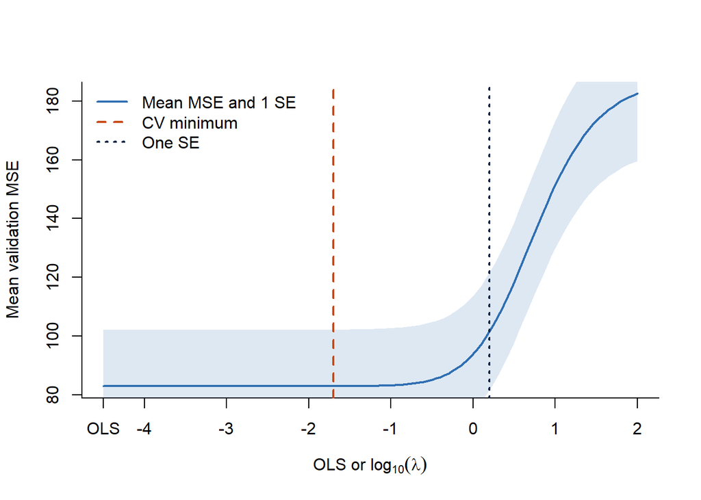

```r
# Preprocess each training fold once, then reuse it for every penalty.
fold_levels <- sort(unique(folds))

# Rows are folds; columns are penalties. Store results
fold_mse <- matrix(
  NA_real_,
  nrow = length(fold_levels),
  ncol = length(lambda_grid)
)

for (k in seq_along(fold_levels)) {
  validation <- folds == fold_levels[k] #T/F vector
  X_fold_train_raw <- X_train_raw[!validation, , drop = FALSE]
  X_fold_validation_raw <- X_train_raw[validation, , drop = FALSE]
  y_fold_train <- y_train[!validation]
  y_fold_validation <- y_train[validation]

  x_bar <- colMeans(X_fold_train_raw)
  X_centered <- sweep(
    X_fold_train_raw, 2, x_bar, "-"
  )
  s <- sqrt(colMeans(X_centered^2))
  X <- sweep(
    X_centered, 2, s, "/"
  )
  # Note that we center and scale the validation fold using the training fold's means and standard deviations.
  X_validation <- sweep(
    X_fold_validation_raw, 2, x_bar, "-"
  )
  X_validation <- sweep(
    X_validation, 2, s, "/"
  )

  y_bar <- mean(y_fold_train)
  y_centered <- y_fold_train - y_bar
  n <- nrow(X)
  p <- ncol(X)
  gram <- crossprod(X)
  rhs <- crossprod(X, y_centered)

  for (l in seq_along(lambda_grid)) {
    lambda <- lambda_grid[l]
    # (XTX + n * lambda * I) Beta \= XTy_centered
    beta_hat <- solve(
      gram + n * lambda * diag(p),
      rhs
    )
    y_hat_validation <- y_bar +
      drop(X_validation %*% beta_hat)
    fold_mse[k, l] <- mean(
      (y_fold_validation - y_hat_validation)^2
    )
  }
}

cv_mean <- colMeans(fold_mse)
cv_se <- apply(fold_mse, 2, sd) / sqrt(nrow(fold_mse))
min_index <- which.min(cv_mean)
lambda_min <- lambda_grid[min_index]
one_se_limit <- cv_mean[min_index] + cv_se[min_index]
lambda_1se <- max(lambda_grid[cv_mean <= one_se_limit])

# GCV uses one fixed full-training smoother across the penalty grid.
x_bar <- colMeans(X_train_raw)
X_centered <- sweep(X_train_raw, 2, x_bar, "-")
s <- sqrt(colMeans(X_centered^2))
X <- sweep(X_centered, 2, s, "/")
y_bar <- mean(y_train)
y_centered <- y_train - y_bar
n <- nrow(X)
p <- ncol(X)
gram <- crossprod(X)
rhs <- crossprod(X, y_centered)
singular_values <- svd(X, nu = 0, nv = 0)$d

gcv <- df_eff_path <- numeric(length(lambda_grid))
for (l in seq_along(lambda_grid)) {
  lambda <- lambda_grid[l]
  beta_hat <- solve(
    gram + n * lambda * diag(p),
    rhs
  )
  y_hat <- y_bar + drop(X %*% beta_hat)
  df_eff_path[l] <- 1 + sum(
    singular_values^2 /
      (singular_values^2 + n * lambda)
  )
  training_mse <- mean((y_train - y_hat)^2)
  gcv[l] <- training_mse /
    (1 - df_eff_path[l] / n)^2
}
lambda_gcv <- lambda_grid[which.min(gcv)]

positive <- lambda_grid > 0
positive_log_lambda <- log10(lambda_grid[positive])
ols_position <- min(positive_log_lambda) - 0.5
plot_position <- rep(ols_position, length(lambda_grid))
plot_position[positive] <- positive_log_lambda
penalty_position <- function(lambda) {
  if (lambda == 0) ols_position else log10(lambda)
}

axis_ticks <- pretty(range(positive_log_lambda))

plot(
  plot_position,
  cv_mean,
  type = "n",
  xaxt = "n",
  xlab = expression(paste("OLS or ", log[10](lambda))),
  ylab = "Mean validation MSE",
  bty = "l"
)
axis(
  1,
  at = c(ols_position, axis_ticks),
  labels = c("OLS", axis_ticks)
)
polygon(
  c(plot_position, rev(plot_position)),
  c(
    cv_mean - cv_se,
    rev(cv_mean + cv_se)
  ),
  col = adjustcolor("#2F6FB3", alpha.f = 0.16),
  border = NA
)
lines(plot_position, cv_mean, col = "#2F6FB3", lwd = 2)
abline(
  v = penalty_position(lambda_min),
  col = "#C84A16",
  lty = 2,
  lwd = 2
)
abline(
  v = penalty_position(lambda_1se),
  col = "#13294B",
  lty = 3,
  lwd = 2
)
legend(
  "topleft",
  legend = c("Mean MSE and 1 SE", "CV minimum", "One SE"),
  col = c("#2F6FB3", "#C84A16", "#13294B"),
  lty = c(1, 2, 3),
  lwd = 2,
  bty = "n"
)
```

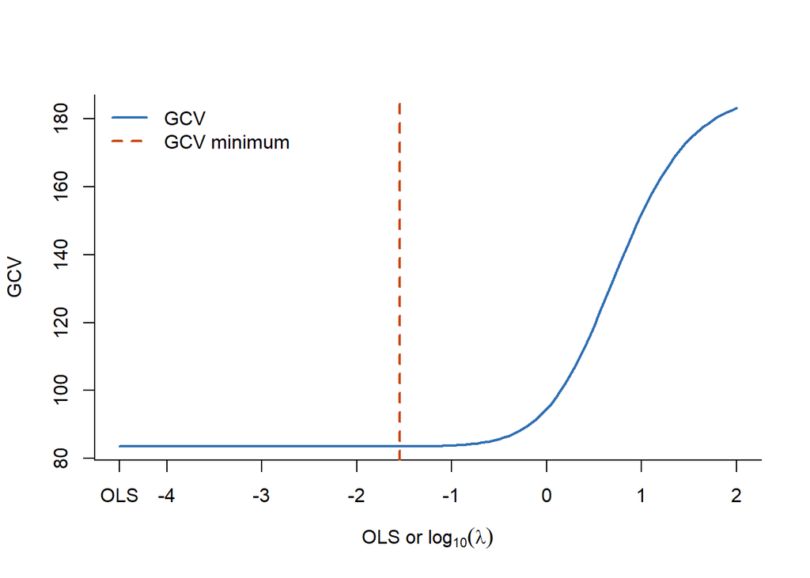

```r
plot(
  plot_position,
  gcv,
  type = "l",
  col = "#2F6FB3",
  lwd = 2,
  xaxt = "n",
  xlab = expression(paste("OLS or ", log[10](lambda))),
  ylab = "GCV",
  bty = "l"
)
axis(
  1,
  at = c(ols_position, axis_ticks),
  labels = c("OLS", axis_ticks)
)
abline(
  v = penalty_position(lambda_gcv),
  col = "#C84A16",
  lty = 2,
  lwd = 2
)
legend(
  "topleft",
  legend = c("GCV", "GCV minimum"),
  col = c("#2F6FB3", "#C84A16"),
  lty = c(1, 2),
  lwd = 2,
  bty = "n"
)
```

# 5c

```r
# Freeze every choice before evaluating the final test responses.
selected <- data.frame(
  rule = c("OLS", "CV minimum", "One SE", "GCV"),
  lambda = c(0, lambda_min, lambda_1se, lambda_gcv)
)
selected$df_eff <- NA_real_
selected$train_mse <- NA_real_
selected$test_mse <- NA_real_

for (l in seq_len(nrow(selected))) {
  fit <- fit_ridge(
    X_train_raw,
    y_train,
    selected$lambda[l],
    X_test_raw
  )
  selected$df_eff[l] <- fit$df_eff
  selected$train_mse[l] <- mean(
    (y_train - fit$y_hat)^2
  )
  selected$test_mse[l] <- mean(
    (y_test - fit$y_hat_new)^2
  )
}

c(lambda_min = lambda_min,
  lambda_1se = lambda_1se,
  lambda_gcv = lambda_gcv,
  one_se_limit = one_se_limit)
```

```
  lambda_min   lambda_1se   lambda_gcv one_se_limit
  0.01995262   1.58489319   0.02818383 102.20756312
```

```r
selected
```

```
        rule     lambda   df_eff train_mse test_mse
1        OLS 0.00000000 7.000000  80.09392 66.32246
2 CV minimum 0.01995262 6.773213  80.13543 65.99957
3     One SE 1.58489319 3.032870 100.37356 81.19981
4        GCV 0.02818383 6.688657  80.17125 65.90276
```

It is never a good idea to use the test response for model selection. The test response should only be used for evaluation after all modeling decisions have been made. Using the test response for model selection can lead to overfitting and biased estimates of model performance. For example, if we were to select the model with the lowest validation MSE, we would be using information from the training set. Even after seeing that the test MSE is lowest for the GCV model, we should still stick to the model selected by the CV minimum rule.

## `explain-to-me` skill

```markdown
---
name: explain-to-me
description: Help the student understand STAT 432 weekly assignment questions and plan an approach without providing direct answers.
---

1. Identify the assignment week from the file or conversation; ask only if it is unclear.
2. Translate each question into clear, manageable tasks, identifying the given information, required work, and expected deliverables.
3. Consult https://teazrq.github.io/stat432rpy/ and link to relevant sections for the corresponding week, briefly explaining how each helps. Verify section titles and links; if the site is unavailable, say so without inventing references.
4. Guide the approach with brief conceptual explanations, hints, and questions that help the student decide the next step.
5. Do not provide direct answers, completed derivations, final numerical results, or submission-ready code or prose. Do not consult solution files; when reviewing an attempt, identify gaps and suggest a next step without completing it.
```